# Problem Set 4: logistic regression, SVM, classification

name: Olivia Tang

## Wisconsin Breast Cancer Dataset

You will work with Wisconsin Breast Cancer Dataset (WBCD), available at UCI Machine Learning Repository. You can download it from the internet but rather use the files wdbc.csv.bz2 and wdbc_doc.txt from canvas (under files/data) where I have added the variable names to the data. The first file is the csv with variable names, the second one a brief description of the data. The data includes diagnosis of the tumor with "M" meaning cancer (malignant) and "B" no cancer (benign), and 10 features, describing physical properties of cell nuclei from biopsy samples. Each feature is represented three times, once for mean, once for standard error, and once for the worst values. Your task is to predict diagnosis based on this data.

```python
#load libraries
import matplotlib
print("Maplotlib version:    %6.6s" % matplotlib.__version__)
%matplotlib inline
# needed for inline plots in notebooks
import matplotlib.pyplot as plt
import seaborn as sns

import numpy as np
import pandas as pd
from sklearn.model_selection import train_test_split
from sklearn.neighbors import KNeighborsClassifier
from sklearn.linear_model import LogisticRegression
from sklearn.preprocessing import MinMaxScaler
from sklearn.svm import SVR
from sklearn.svm import SVC
from sklearn.metrics import confusion_matrix
```

```
Maplotlib version:     2.2.3
```

```python
#reading dataset description
file = open('wdbc_doc.txt', 'r')
print(file.read())
```

```
1. Title: Wisconsin Diagnostic Breast Cancer (WDBC)

2. Source Information

a) Creators:

	Dr. William H. Wolberg, General Surgery Dept., University of
	Wisconsin,  Clinical Sciences Center, Madison, WI 53792
	wolberg@eagle.surgery.wisc.edu

	W. Nick Street, Computer Sciences Dept., University of
	Wisconsin, 1210 West Dayton St., Madison, WI 53706
	street@cs.wisc.edu  608-262-6619

	Olvi L. Mangasarian, Computer Sciences Dept., University of
	Wisconsin, 1210 West Dayton St., Madison, WI 53706
	olvi@cs.wisc.edu

b) Donor: Nick Street

c) Date: November 1995

3. Past Usage:

first usage:

	W.N. Street, W.H. Wolberg and O.L. Mangasarian
	Nuclear feature extraction for breast tumor diagnosis.
	IS&T/SPIE 1993 International Symposium on Electronic Imaging: Science
	and Technology, volume 1905, pages 861-870, San Jose, CA, 1993.

OR literature:

	O.L. Mangasarian, W.N. Street and W.H. Wolberg.
	Breast cancer diagnosis and prognosis via linear programming.
	Operations Research, 43(4), pages 570-577, July-August 1995.

Medical literature:

	W.H. Wolberg, W.N. Street, and O.L. Mangasarian.
```

[output cut: 85 more lines]

```
	j) fractal dimension ("coastline approximation" - 1)

Several of the papers listed above contain detailed descriptions of
how these features are computed.

The mean, standard error, and "worst" or largest (mean of the three
largest values) of these features were computed for each image,
resulting in 30 features.  For instance, field 3 is Mean Radius, field
13 is Radius SE, field 23 is Worst Radius.

All feature values are recoded with four significant digits.

8. Missing attribute values: none

9. Class distribution: 357 benign, 212 malignant
```

### 1 Explore the data

As the first step, explore the data.

1. Load the data. You may drop id or just ignore it in the rest of your analysis.
2. Create a summary table where you show means, ranges, and number of missings for each variable. In addition, add (Pearson) correlation between the diagnosis and the corresponding feature. You may include more statistics you consider useful.
3. Graphical exploration. Make a number of scatterplots where you explore the relationship between features and the diagnosis. Note: you may attempt to display all 435 possible combinations as a scatterplot matrix, but that will most likely be just unreadable. Choose instead a few cases with high correlation and a few with medium/low correlation. Avoid overwhelming your reader with tens of similar figures.

```python
#load data
wdbc_data = pd.read_csv("wdbc.csv.bz2").drop(columns = ['id'])
wdbc_data = wdbc_data.replace(['M', 'B'], [1, 0])

#explore data

summary = (wdbc_data.describe()).T
w = (wdbc_data.corr('pearson')).iloc[0, ]

summary['corr'] = w
summary['isnull'] = wdbc_data.isnull().sum()
summary = summary.sort_values(by = ['corr'])
```

```python
wdbc_data.loc[wdbc_data.diagnosis == 1].sum()
```

```
diagnosis               212.000000
radius.mean            3702.120000
texture.mean           4580.240000
perimeter.mean        24457.460000
area.mean            207415.800000
smoothness.mean          21.814480
compactness.mean         30.779810
concavity.mean           34.084240
concpoints.mean          18.653880
symmetry.mean            40.896700
fracdim.mean             13.288180
radius.se               129.125500
texture.se              256.713900
perimeter.se            916.673000
area.se               15406.550000
smoothness.se             1.437380
compactness.se            6.843607
concavity.se              8.866690
concpoints.se             3.192820
symmetry.se               4.340149
fracdim.se                0.861230
radius.worst           4480.580000
texture.worst          6215.460000
perimeter.worst       29970.510000
area.worst           301524.700000
smoothness.worst         30.707190
compactness.worst        79.462710
concavity.worst          95.528380
concpoints.worst         38.634310
symmetry.worst           68.575200
fracdim.worst            19.404350
dtype: float64
```

```python
#summary table
summary
```

|  | count | mean | std | min | 25% | 50% | 75% | max | corr | isnull |
| --- | --- | --- | --- | --- | --- | --- | --- | --- | --- | --- |
| smoothness.se | 569.0 | 0.007041 | 0.003003 | 0.001713 | 0.005169 | 0.006380 | 0.008146 | 0.03113 | -0.067016 | 0 |
| fracdim.mean | 569.0 | 0.062798 | 0.007060 | 0.049960 | 0.057700 | 0.061540 | 0.066120 | 0.09744 | -0.012838 | 0 |
| texture.se | 569.0 | 1.216853 | 0.551648 | 0.360200 | 0.833900 | 1.108000 | 1.474000 | 4.88500 | -0.008303 | 0 |
| symmetry.se | 569.0 | 0.020542 | 0.008266 | 0.007882 | 0.015160 | 0.018730 | 0.023480 | 0.07895 | -0.006522 | 0 |
| fracdim.se | 569.0 | 0.003795 | 0.002646 | 0.000895 | 0.002248 | 0.003187 | 0.004558 | 0.02984 | 0.077972 | 0 |
| concavity.se | 569.0 | 0.031894 | 0.030186 | 0.000000 | 0.015090 | 0.025890 | 0.042050 | 0.39600 | 0.253730 | 0 |
| compactness.se | 569.0 | 0.025478 | 0.017908 | 0.002252 | 0.013080 | 0.020450 | 0.032450 | 0.13540 | 0.292999 | 0 |
| fracdim.worst | 569.0 | 0.083946 | 0.018061 | 0.055040 | 0.071460 | 0.080040 | 0.092080 | 0.20750 | 0.323872 | 0 |
| symmetry.mean | 569.0 | 0.181162 | 0.027414 | 0.106000 | 0.161900 | 0.179200 | 0.195700 | 0.30400 | 0.330499 | 0 |
| smoothness.mean | 569.0 | 0.096360 | 0.014064 | 0.052630 | 0.086370 | 0.095870 | 0.105300 | 0.16340 | 0.358560 | 0 |
| concpoints.se | 569.0 | 0.011796 | 0.006170 | 0.000000 | 0.007638 | 0.010930 | 0.014710 | 0.05279 | 0.408042 | 0 |
| texture.mean | 569.0 | 19.289649 | 4.301036 | 9.710000 | 16.170000 | 18.840000 | 21.800000 | 39.28000 | 0.415185 | 0 |
| symmetry.worst | 569.0 | 0.290076 | 0.061867 | 0.156500 | 0.250400 | 0.282200 | 0.317900 | 0.66380 | 0.416294 | 0 |
| smoothness.worst | 569.0 | 0.132369 | 0.022832 | 0.071170 | 0.116600 | 0.131300 | 0.146000 | 0.22260 | 0.421465 | 0 |
| texture.worst | 569.0 | 25.677223 | 6.146258 | 12.020000 | 21.080000 | 25.410000 | 29.720000 | 49.54000 | 0.456903 | 0 |
| area.se | 569.0 | 40.337079 | 45.491006 | 6.802000 | 17.850000 | 24.530000 | 45.190000 | 542.20000 | 0.548236 | 0 |
| perimeter.se | 569.0 | 2.866059 | 2.021855 | 0.757000 | 1.606000 | 2.287000 | 3.357000 | 21.98000 | 0.556141 | 0 |
| radius.se | 569.0 | 0.405172 | 0.277313 | 0.111500 | 0.232400 | 0.324200 | 0.478900 | 2.87300 | 0.567134 | 0 |
| compactness.worst | 569.0 | 0.254265 | 0.157336 | 0.027290 | 0.147200 | 0.211900 | 0.339100 | 1.05800 | 0.590998 | 0 |
| compactness.mean | 569.0 | 0.104341 | 0.052813 | 0.019380 | 0.064920 | 0.092630 | 0.130400 | 0.34540 | 0.596534 | 0 |
| concavity.worst | 569.0 | 0.272188 | 0.208624 | 0.000000 | 0.114500 | 0.226700 | 0.382900 | 1.25200 | 0.659610 | 0 |
| concavity.mean | 569.0 | 0.088799 | 0.079720 | 0.000000 | 0.029560 | 0.061540 | 0.130700 | 0.42680 | 0.696360 | 0 |
| area.mean | 569.0 | 654.889104 | 351.914129 | 143.500000 | 420.300000 | 551.100000 | 782.700000 | 2501.00000 | 0.708984 | 0 |
| radius.mean | 569.0 | 14.127292 | 3.524049 | 6.981000 | 11.700000 | 13.370000 | 15.780000 | 28.11000 | 0.730029 | 0 |
| area.worst | 569.0 | 880.583128 | 569.356993 | 185.200000 | 515.300000 | 686.500000 | 1084.000000 | 4254.00000 | 0.733825 | 0 |
| perimeter.mean | 569.0 | 91.969033 | 24.298981 | 43.790000 | 75.170000 | 86.240000 | 104.100000 | 188.50000 | 0.742636 | 0 |
| radius.worst | 569.0 | 16.269190 | 4.833242 | 7.930000 | 13.010000 | 14.970000 | 18.790000 | 36.04000 | 0.776454 | 0 |
| concpoints.mean | 569.0 | 0.048919 | 0.038803 | 0.000000 | 0.020310 | 0.033500 | 0.074000 | 0.20120 | 0.776614 | 0 |
| perimeter.worst | 569.0 | 107.261213 | 33.602542 | 50.410000 | 84.110000 | 97.660000 | 125.400000 | 251.20000 | 0.782914 | 0 |
| concpoints.worst | 569.0 | 0.114606 | 0.065732 | 0.000000 | 0.064930 | 0.099930 | 0.161400 | 0.29100 | 0.793566 | 0 |
| diagnosis | 569.0 | 0.372583 | 0.483918 | 0.000000 | 0.000000 | 0.000000 | 1.000000 | 1.00000 | 1.000000 | 0 |

```python
wdbc_sample = wdbc_data[['diagnosis', 'concpoints.worst', 'perimeter.worst', 'area.worst', 'concavity.mean',
                        'compactness.mean', 'fracdim.worst', 'symmetry.se']]
```

```python
#
summary.index
```

```
Index(['smoothness.se', 'fracdim.mean', 'texture.se', 'symmetry.se',
       'fracdim.se', 'concavity.se', 'compactness.se', 'fracdim.worst',
       'symmetry.mean', 'smoothness.mean', 'concpoints.se', 'texture.mean',
       'symmetry.worst', 'smoothness.worst', 'texture.worst', 'area.se',
       'perimeter.se', 'radius.se', 'compactness.worst', 'compactness.mean',
       'concavity.worst', 'concavity.mean', 'area.mean', 'radius.mean',
       'area.worst', 'perimeter.mean', 'radius.worst', 'concpoints.mean',
       'perimeter.worst', 'concpoints.worst', 'diagnosis'],
      dtype='object')
```

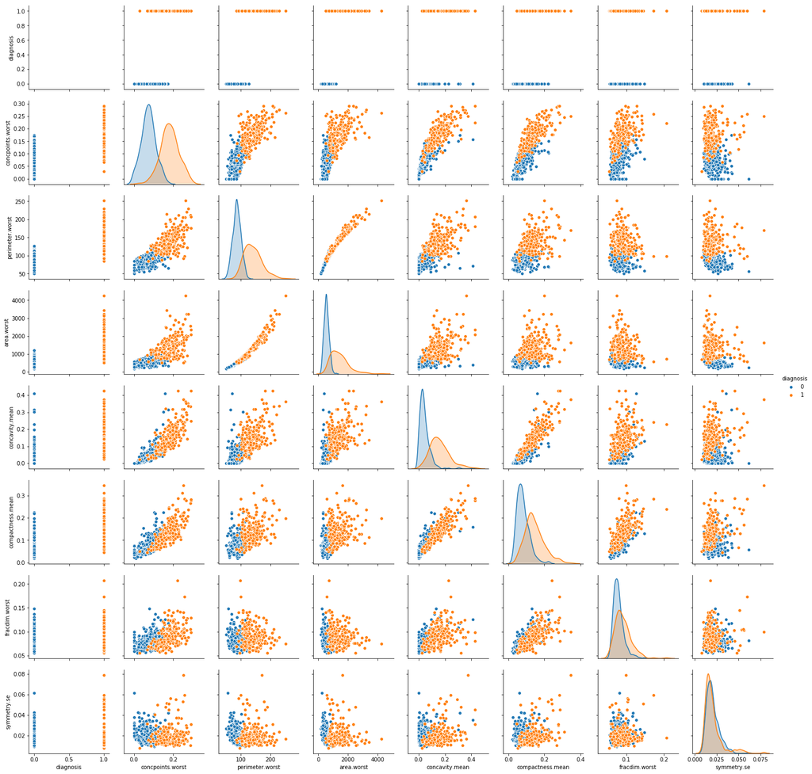

```python
#scatterplot matrix of coorelation of certain features
sns.pairplot(wdbc_sample, hue = 'diagnosis')
```

### 2 Decision Boundary

Your next task is to plot the decision boundary when using logistic regression. You will also play a little with feature engineering. If you are uncertain about what is decision boundary, I recommend to consult James et al. (2015) book Section 2. For instance, Figure 2.13 on p38 depicts a 2D classification case where certain X1, X2 values are classified as orange and others as blue. Decision boundary is the dashed winding line that separates these two regions. There are two broad strategies to plot it. In any case, you have first to estimate (train) your model. Thereafter you have to predict the classes (cancer/no cancer here) on a regular dense grid that covers the parameter space (this is the small blue/orange dots on figure 2.13). Afterwards you can either plot your predicted values with a certain color code, or alternatively, say, set predicted M to 1 and predicted B to 0, and make a contour plot for a single contour at level 0.5. You may also combine these both methods. Some example code in R is provided here, python version will be in a separate file. We ignore training/testing/overfitting issues for now.

### 2.1 kNN Case

First, let's explore the decision boundary using k-NN. Pick two features. I recommend to use a few that show relative strong correlation with diagnosis, and that vary widely across the scatterplot (not just highly correlated narrow line). Feel free to use a combination you already plotted above.

1. Predict the diagnosis on a grid (say, 100 × 100, or less if this is too slow) that covers the range of the explanatory variables. Use k-NN with k = 3..7 (pick just one value). This gives you 100x100 predicted diagnoses. See the example code. Note: if your features are of very different scale, you should either scale these into a roughly equal scale, or use a metric that does this with you. Consult James et al. (2015, p 217).
2. Plot the actual data and the decision boundary on the same plot. Ensure that actual observations and predictions are clearly distinguishable, and that one can easily understand the color code. Here is an example code in R on how you may do this. We just generate some random data and use logistic regression.

using concpoints.worst, and area.worst

```python
#scale data from columns and take sample of 100 rows
scaler = MinMaxScaler()
wdbc_s = (wdbc_sample[['diagnosis','concpoints.worst', 'area.worst']]).sample(100)
wdbc_scale = scaler.fit_transform(wdbc_s[['concpoints.worst', 'area.worst']])

#making each column it's own variable to be easier later
concw = pd.Series(data = wdbc_scale[:, 0])
areaw = pd.Series(wdbc_scale[:, 1])
diag = np.asarray(wdbc_s['diagnosis'])
```

[figure not shown]

```python
#plot for knn

m = KNeighborsClassifier(n_neighbors = 4).fit(wdbc_scale, wdbc_s['diagnosis'])
## Now create the regular grid
ex1 = np.linspace(concw.min(), concw.max(), 100)
ex2 = np.linspace(areaw.min(), areaw.max(), 100)
xx1, xx2 = np.meshgrid(ex1, ex2)

# unlike R-s 'expand.grid', meshgrid creates matrices
g = np.stack((xx1.ravel(), xx2.ravel()), axis=1)
# we create the design matrix by stacking the xx1, xx2
# after unraveling those into columns
## predict on the grid
hatY = m.predict(g).reshape(100,100)
# imshow wants a mtrix, so we reshape the predicted vector
#into one
plt.imshow(hatY, extent=(concw.min(), concw.max(), areaw.min(), areaw.max()),
interpolation='none', origin='lower',
# you need to specify that the image begins from below,
# not above, otherwise it will be flipped around
alpha=0.3)
plt.scatter(concw, areaw, c=diag)
plt.show()
```

1. Describe your observations. How good is kNN in picking up the actual shape? Does it also pick up noise? Note: unless you do cross-validation, you cannot know if the model picks up noise (overfit). Here I just ask your best judgement, not any formal analysis.

knn seems to be good at picking up the shape. It seems to pick up noise since at the boundary some points of yellow bleed into the purple boundary, and in that area there is a lot of purple.

### 2.2 Logistic Regression

Now repeat the process above by logistic regression. Pick the same features as what you used for k-NN above.

1. Fit a logistic regression model with these two features.
2. Predict the diagnosis on a similar grid. . .
3. . . . and create a similar plot.

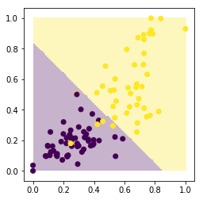

```python
#create a plot for logistic regression
m = LogisticRegression().fit(wdbc_scale, wdbc_s['diagnosis'])
## Now create the regular grid
ex1 = np.linspace(concw.min(), concw.max(), 100)
ex2 = np.linspace(areaw.min(), areaw.max(), 100)
xx1, xx2 = np.meshgrid(ex1, ex2)

# unlike R-s 'expand.grid', meshgrid creates matrices
g = np.stack((xx1.ravel(), xx2.ravel()), axis=1)
# we create the design matrix by stacking the xx1, xx2
# after unraveling those into columns
## predict on the grid
hatY = m.predict(g).reshape(100,100)
# imshow wants a mtrix, so we reshape the predicted vector
#into one
plt.imshow(hatY, extent=(concw.min(), concw.max(), areaw.min(), areaw.max()),
interpolation='none', origin='lower',
# you need to specify that the image begins from below,
# not above, otherwise it will be flipped around
alpha=0.3)
plt.scatter(concw, areaw, c=diag)
plt.show()
```

1. Describe your observations. How does the result for kNN compare to that for Logistic Regression?

knn seems to have a better boundary than logistic regression because less points bleed into other boundaries and the boundaries is less linear and fits the data.

### 2.3 Feature Engineering

So far you were using just two of the existing features in the data. However, now let's create a few more.

1. Fit a logistic regression model. However, this time pick both x1, x2, and some of your engineered features.
2. Create the decision boundary plot. Although you now have more than two features, you still plot it using the x1-x2 axes as above. This is because all your engineered features are functionally dependent on x1 and x2 only: if we know values of x1 and x2, we also know exactly the values of your engineered features. We have more than two features but these are not independent (but they should still be linearily independent).

```python
#creating engineered features and putting them into df
wdbc_fe = pd.DataFrame(data = wdbc_scale)
wdbc_fe.columns = ['concpoints.worst', 'area.worst']
wdbc_fe['cwsq'] = np.square(wdbc_fe['concpoints.worst'])
wdbc_fe['awsq'] = np.square(wdbc_fe['area.worst'])
wdbc_fe['ctimesa'] = wdbc_fe['concpoints.worst'] * wdbc_fe['area.worst']
wdbc_fe.head()
```

|  | concpoints.worst | area.worst | cwsq | awsq | ctimesa |
| --- | --- | --- | --- | --- | --- |
| 0 | 0.000000 | 0.000000 | 0.000000 | 0.000000 | 0.000000 |
| 1 | 0.114089 | 0.254739 | 0.013016 | 0.064892 | 0.029063 |
| 2 | 0.332518 | 0.141196 | 0.110568 | 0.019936 | 0.046950 |
| 3 | 0.724079 | 0.696111 | 0.524290 | 0.484571 | 0.504039 |
| 4 | 0.117568 | 0.125073 | 0.013822 | 0.015643 | 0.014705 |

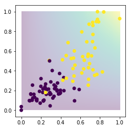

```python
m = LogisticRegression().fit(wdbc_scale, wdbc_s['diagnosis'])
## Now create the regular grid
ex1 = np.linspace(concw.min(), concw.max(), 100)
ex2 = np.linspace(areaw.min(), areaw.max(), 100)
xx1, xx2 = np.meshgrid(ex1, ex2)
xx3 = xx1 *xx2
# unlike R-s 'expand.grid', meshgrid creates matrices
g = np.stack((xx1.ravel(), xx2.ravel()), axis=1)

# we create the design matrix by stacking the xx1, xx2
# after unraveling those into columns
## predict on the grid
hatY = m.predict(g).reshape(100,100)
hatY = np.stack((hatY, xx3), axis = 1)

# imshow wants a mtrix, so we reshape the predicted vector
#into one
plt.imshow(hatY[:,1], extent=(concw.min(), concw.max(), areaw.min(), areaw.max()),
interpolation='none', origin='lower',
# you need to specify that the image begins from below,
# not above, otherwise it will be flipped around
alpha=0.3)
plt.scatter(concw, areaw, c=diag)
plt.show()
```

1. Comment on the shape of the boundary. What do you think, how well can you capture the actual boundary? What about overfitting? (Again, I ask about your judgement, not about any formal analysis).

I think the boundary is really similar to when there was no feature engineering if not more skewed towards the yellow.

1. Repeat the exercise a few times where you pick/engineer different new features, and try to get as reasonable boundary as you can. As above, I am asking reasonable boundary in the sense of your best judgement. No actual cross validation is necessary.

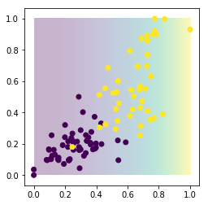

```python
m = LogisticRegression().fit(wdbc_scale, wdbc_s['diagnosis'])
## Now create the regular grid
ex1 = np.linspace(concw.min(), concw.max(), 100)
ex2 = np.linspace(areaw.min(), areaw.max(), 100)
xx1, xx2 = np.meshgrid(ex1, ex2)
xx3 = xx1**2
# unlike R-s 'expand.grid', meshgrid creates matrices
g = np.stack((xx1.ravel(), xx2.ravel()), axis=1)

# we create the design matrix by stacking the xx1, xx2
# after unraveling those into columns
## predict on the grid
hatY = m.predict(g).reshape(100,100)
hatY = np.stack((hatY, xx3), axis = 1)

# imshow wants a mtrix, so we reshape the predicted vector
#into one
plt.imshow(hatY[:,1], extent=(concw.min(), concw.max(), areaw.min(), areaw.max()),
interpolation='none', origin='lower',
# you need to specify that the image begins from below,
# not above, otherwise it will be flipped around
alpha=0.3)
plt.scatter(concw, areaw, c=diag)
plt.show()
```

This boundary is less accurate and skewed towards xx1 data

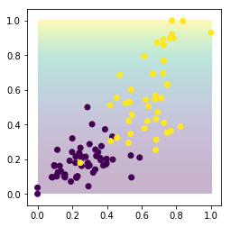

```python
m = LogisticRegression().fit(wdbc_scale, wdbc_s['diagnosis'])
## Now create the regular grid
ex1 = np.linspace(concw.min(), concw.max(), 100)
ex2 = np.linspace(areaw.min(), areaw.max(), 100)
xx1, xx2 = np.meshgrid(ex1, ex2)
xx3 = xx2**2
# unlike R-s 'expand.grid', meshgrid creates matrices
g = np.stack((xx1.ravel(), xx2.ravel()), axis=1)

# we create the design matrix by stacking the xx1, xx2
# after unraveling those into columns
## predict on the grid
hatY = m.predict(g).reshape(100,100)
hatY = np.stack((hatY, xx3), axis = 1)

# imshow wants a mtrix, so we reshape the predicted vector
#into one
plt.imshow(hatY[:,1], extent=(concw.min(), concw.max(), areaw.min(), areaw.max()),
interpolation='none', origin='lower',
# you need to specify that the image begins from below,
# not above, otherwise it will be flipped around
alpha=0.3)
plt.scatter(concw, areaw, c=diag)
plt.show()
```

This boundary is less accurate and skewed towards xx2 data

### 2.4 Support Vector Machines

As you may have guessed, here your task is to do essentially the same thing but using SVM instead of the other methods. Use the same features what what you used above for k-NN and logistic, but instead of playing with feature engineering, you will play with different kernels.

1. Fit a SVM regression model with these two features.
2. Predict the diagnosis on a similar grid. . .
3. . . . and create a similar plot.
4. repeat with a few different kernels (check the software documentation about how to choose kernels and related parameters).

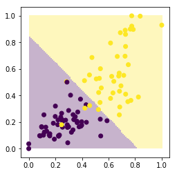

```python
#testing kernal rbf
m = SVC().fit(wdbc_scale, wdbc_s['diagnosis'])

## Now create the regular grid
ex1 = np.linspace(concw.min(), concw.max(), 100)
ex2 = np.linspace(areaw.min(), areaw.max(), 100)
xx1, xx2 = np.meshgrid(ex1, ex2)

# unlike R-s 'expand.grid', meshgrid creates matrices
g = np.stack((xx1.ravel(), xx2.ravel()), axis=1)
# we create the design matrix by stacking the xx1, xx2
# after unraveling those into columns
## predict on the grid
hatY = m.predict(g).reshape(100,100)
# imshow wants a mtrix, so we reshape the predicted vector
#into one
plt.imshow(hatY, extent=(concw.min(), concw.max(), areaw.min(), areaw.max()),
interpolation='none', origin='lower',
# you need to specify that the image begins from below,
# not above, otherwise it will be flipped around
alpha=0.3)
plt.scatter(concw, areaw, c=diag)
plt.show()
```

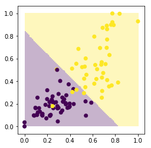

```python
#testing kernal linear
m = SVC(kernel = 'linear').fit(wdbc_scale, wdbc_s['diagnosis'])

## Now create the regular grid
ex1 = np.linspace(concw.min(), concw.max(), 100)
ex2 = np.linspace(areaw.min(), areaw.max(), 100)
xx1, xx2 = np.meshgrid(ex1, ex2)

# unlike R-s 'expand.grid', meshgrid creates matrices
g = np.stack((xx1.ravel(), xx2.ravel()), axis=1)
# we create the design matrix by stacking the xx1, xx2
# after unraveling those into columns
## predict on the grid
hatY = m.predict(g).reshape(100,100)
# imshow wants a mtrix, so we reshape the predicted vector
#into one
plt.imshow(hatY, extent=(concw.min(), concw.max(), areaw.min(), areaw.max()),
interpolation='none', origin='lower',
# you need to specify that the image begins from below,
# not above, otherwise it will be flipped around
alpha=0.3)
plt.scatter(concw, areaw, c=diag)
plt.show()
```

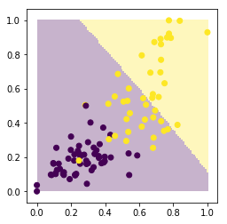

```python
#testing kernal poly
m = SVC(kernel = 'poly').fit(wdbc_scale, wdbc_s['diagnosis'])

## Now create the regular grid
ex1 = np.linspace(concw.min(), concw.max(), 100)
ex2 = np.linspace(areaw.min(), areaw.max(), 100)
xx1, xx2 = np.meshgrid(ex1, ex2)

# unlike R-s 'expand.grid', meshgrid creates matrices
g = np.stack((xx1.ravel(), xx2.ravel()), axis=1)
# we create the design matrix by stacking the xx1, xx2
# after unraveling those into columns
## predict on the grid
hatY = m.predict(g).reshape(100,100)
# imshow wants a mtrix, so we reshape the predicted vector
#into one
plt.imshow(hatY, extent=(concw.min(), concw.max(), areaw.min(), areaw.max()),
interpolation='none', origin='lower',
# you need to specify that the image begins from below,
# not above, otherwise it will be flipped around
alpha=0.3)
plt.scatter(concw, areaw, c=diag)
plt.show()
```

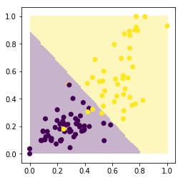

```python
#testing kernal sigmoid
m = SVC(kernel = 'sigmoid').fit(wdbc_scale, wdbc_s['diagnosis'])

## Now create the regular grid
ex1 = np.linspace(concw.min(), concw.max(), 100)
ex2 = np.linspace(areaw.min(), areaw.max(), 100)
xx1, xx2 = np.meshgrid(ex1, ex2)

# unlike R-s 'expand.grid', meshgrid creates matrices
g = np.stack((xx1.ravel(), xx2.ravel()), axis=1)
# we create the design matrix by stacking the xx1, xx2
# after unraveling those into columns
## predict on the grid
hatY = m.predict(g).reshape(100,100)
# imshow wants a mtrix, so we reshape the predicted vector
#into one
plt.imshow(hatY, extent=(concw.min(), concw.max(), areaw.min(), areaw.max()),
interpolation='none', origin='lower',
# you need to specify that the image begins from below,
# not above, otherwise it will be flipped around
alpha=0.3)
plt.scatter(concw, areaw, c=diag)
plt.show()
```

1. Describe your observations. Which kernel gives the most reasonable results? How does the result for kNN compare to that for Logistic Regression?

linear, rbf, and sigmoid gave me the most reasonable results. the result for these seems to be the most similar to logistic regression, knn still seems to have the best shape for the boundary.